# Model building: Time-series decomposition for birthdays

```r
summarise_draws(subset(draws7, variable = c("beta_f3"))) |>
  tt()
```

| variable | mean | median | sd | mad | q5 | q95 | rhat | ess_bulk | ess_tail |
| --- | --- | --- | --- | --- | --- | --- | --- | --- | --- |
| beta_f3[1] | 0.31 | 0.31 | 0.011 | 0.011 | 0.29 | 0.33 | 1 | 508 | 291 |
| beta_f3[2] | 0.075 | 0.074 | 0.012 | 0.011 | 0.056 | 0.096 | 1 | 503 | 211 |
| beta_f3[3] | 0.029 | 0.028 | 0.012 | 0.012 | 0.011 | 0.048 | 1 | 456 | 375 |
| beta_f3[4] | 0.14 | 0.14 | 0.012 | 0.012 | 0.12 | 0.16 | 1 | 477 | 374 |
| beta_f3[5] | -1.2 | -1.2 | 0.012 | 0.013 | -1.2 | -1.1 | 1 | 569 | 244 |
| beta_f3[6] | -1.6 | -1.6 | 0.012 | 0.011 | -1.6 | -1.6 | 1 | 385 | 294 |

Compare the model to the data

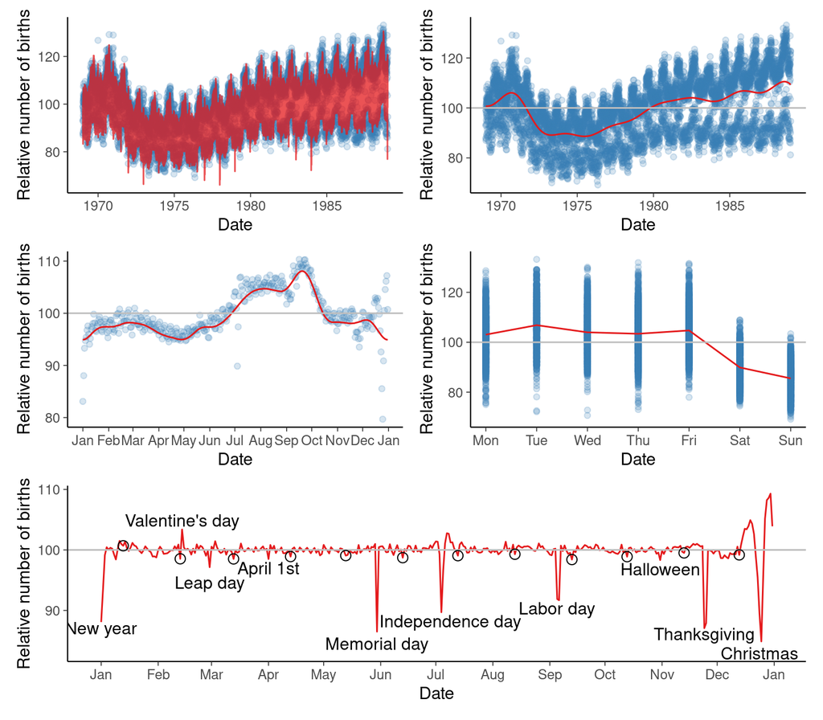

Figure 32

```r
draws7 <- as_draws_matrix(draws7)
Ef <- exp(apply(subset(draws7, variable = "f"), 2, median))
Ef1 <- apply(subset(draws7, variable = "f1"), 2, median)
Ef1 <- exp(Ef1 - mean(Ef1) + mean(log(birthdays$births_relative100)))
Ef2 <- apply(subset(draws7, variable = "f2"), 2, median)
Ef2 <- exp(Ef2 - mean(Ef2) + mean(log(birthdays$births_relative100)))
Ef_day_of_week <- apply(subset(draws7, variable = "f_day_of_week"), 2, median)
Ef_day_of_week <- exp(Ef_day_of_week - mean(Ef_day_of_week) + mean(log(birthdays$births_relative100)))
Ef4 <- apply(subset(draws7, variable = "beta_f4"), 2, median) * sd(log(birthdays$births_relative100))
Ef4 <- exp(Ef4) * 100
Efloats <- apply(subset(draws7, variable = "beta_f5"), 2, median) * sd(log(birthdays$births_relative100))
Efloats <- exp(Efloats) * 100
floats1988 <- c(memorial_days[20], labor_days[c(20, 40)], thanksgiving_days[c(20, 40)]) - 6939
Ef4float <- Ef4
Ef4float[floats1988] <- Ef4float[floats1988] * Efloats[c(1, 2, 2, 3, 3)] / 100
pf   <- make_pf(birthdays, Ef)
pf1  <- make_pf1(birthdays, Ef1)
pf2  <- make_pf2(birthdays, Ef2)
pf3  <- make_pf3(birthdays, Ef_day_of_week)
f13  <- birthdays |> filter(year == 1988) |> select(day, date) |> mutate(y = Ef4float) |> filter(day == 13)
pf2b <- make_pf2b(Ef4float, f13, holidays = "floating")
compose_6panel(pf, pf1, pf2, pf3, pf2b)
```

The day of year and floating special day effects are shown for year 1988 (which is also a leap year) and the results seem reasonable.

Compare the mean and sd of parameters from Pathfinder and MCMC. In this case, we are using the non-resampled Pathfinder draws.

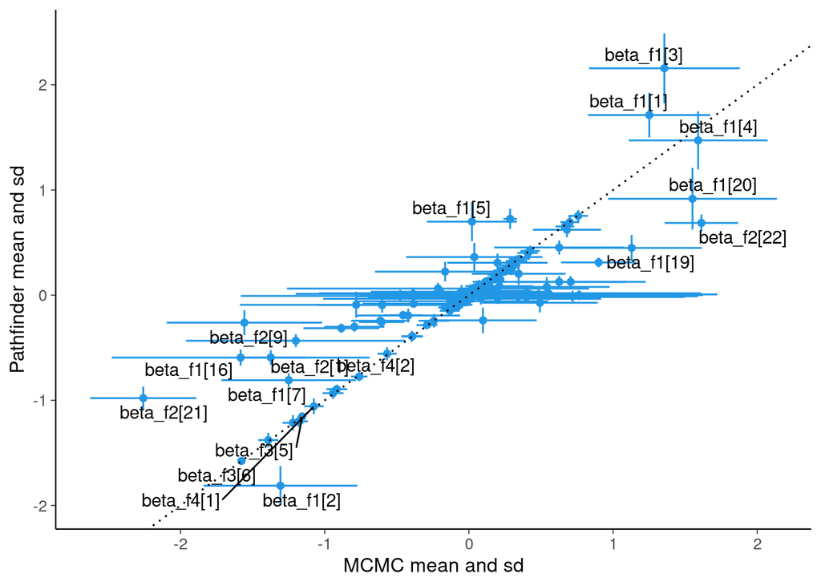

Figure 33

```r
variables <- names(model7$variables()$parameters)
sp <- summarise_draws(subset(pth7$draws(), variable = variables))
sm <- summarise_draws(subset(draws7, variable = variables))
make_pth_vs_fit(sm, sp)
```

The following plot shows the day of year effect with 90% posterior intervals.

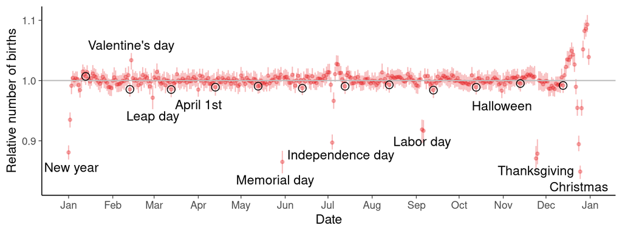

Figure 34

```r
draws7r <- as_draws_rvars(draws7)
Ef4r <- exp(draws7r$beta_f4*sd(log(birthdays$births_relative100)))
Efloatsr <- exp(draws7r$beta_f5*sd(log(birthdays$births_relative100)))
floats1988 <- c(memorial_days[20], labor_days[c(20, 40)], thanksgiving_days[c(20, 40)]) - 6939
Ef4floatr <- Ef4r
Ef4floatr[floats1988] <- Ef4floatr[floats1988] * Efloatsr[c(1, 2, 2, 3, 3)]
draws7 <- as_draws_matrix(draws7)
Ef4 <- apply(subset(draws7, variable = "beta_f4"), 2, median) * sd(log(birthdays$births_relative100))
Ef4 <- exp(Ef4)
Efloats <- apply(subset(draws7, variable = "beta_f5"), 2, median) * sd(log(birthdays$births_relative100))
Efloats <- exp(Efloats)
floats1988 <- c(memorial_days[20], labor_days[c(20, 40)], thanksgiving_days[c(20, 40)]) - 6939
Ef4float <- Ef4
Ef4float[floats1988] <- Ef4float[floats1988] * Efloats[c(1, 2, 2, 3, 3)]
f13  <- birthdays |> filter(year == 1988) |> select(day, date) |> mutate(y = Ef4float) |> filter(day == 13)
pf2c <- make_pf2c(Ef4float, Ef4floatr, f13, holidays = "floating")
pf2c
```

In this plot, it seems like almost all 13th days have fewer births. If we look at the mean effect over all 13th days, the probability that the relative number of births is less than 1 is 100%, although with a small estimated effect of 0.9% fewer births.

## 5.8 Model 8: long term smooth + seasonal + weekday with time dependent magnitude + day of year + special

As the day of year and floating day effects work well, we’ll add the time dependent day of week effect back to the model.

Compile Stan model 8 gpbf8.stan

```r
model8 <- cmdstan_model(stan_file = root("birthdays", "gpbf8.stan"),
                        include_paths = root("birthdays"))
```

Floating special days

```r
# Memorial day
memorial_days <- with(birthdays, which(month == 5 & day_of_week == 1 & day >= 25))
# Labor day
labor_days <- with(birthdays, which(month == 9 & day_of_week == 1 & day <= 7))
labor_days <- c(labor_days, labor_days + 1)
# Thanksgiving
thanksgiving_days <- with(birthdays, which(month == 11 & day_of_week == 4 & day >= 22 & day <= 28))
thanksgiving_days <- c(thanksgiving_days, thanksgiving_days + 1)
```

Data to be passed to Stan

```r
standata8 <- list(x = birthdays$id,
                  y = log(birthdays$births_relative100),
                  N = length(birthdays$id),
                  c_f1 = 1.5, # factor c of basis functions for GP for f1
                  M_f1 = 20,  # number of basis functions for GP for f1
                  J_f2 = 20,  # number of basis functions for periodic f2
                  c_g3 = 1.5, # factor c of basis functions for GP for g3
                  M_g3 = 5,   # number of basis functions for GP for g3
                  day_of_week = birthdays$day_of_week,
                  day_of_year = birthdays$day_of_year2, # 1st March = 61 every year
                  memorial_days = memorial_days,
                  labor_days = labor_days,
                  thanksgiving_days = thanksgiving_days)
```

Pathfinder is faster than sampling (although this result can be useful in a quick workflow, the result should not be used as the final result).

```r
tic('Sampling from Pathfinder approximation of model 8 posterior')
pth8 <- model8$pathfinder(data = standata8, init = 0.1,
                          num_paths = 10, single_path_draws = 40, draws = 400,
                          history_size = 50, max_lbfgs_iters = 100,
                          refresh = 0)
```

```
Pareto k value (7.3) is greater than 0.7. Importance resampling was not able to improve the approximation, which may indicate that the approximation itself is poor.
Finished in  10.0 seconds.
```

```r
mytoc()
```

Check whether parameters have reasonable values

```r
pdraws8 <- pth8$draws()
summarise_draws(subset(pdraws8, variable = c("lp__")), n_distinct) |>
  tt()
```

| variable | n_distinct |
| --- | --- |
| lp__ | 2 |

```r
summarise_draws(subset(pdraws8, variable = c("sigma_", "lengthscale_", "sigma"), regex = TRUE),
                default_summary_measures()) |>
  tt()
```

| variable | mean | median | sd | mad | q5 | q95 |
| --- | --- | --- | --- | --- | --- | --- |
| sigma_f1 | 0.64 | 0.64 | 0.00048 | 0 | 0.64 | 0.64 |
| sigma_f2 | 0.63 | 0.63 | 0.0012 | 0 | 0.63 | 0.63 |
| sigma_g3 | 0.25 | 0.25 | 0.00037 | 0 | 0.25 | 0.25 |
| sigma_f4 | 0.16 | 0.16 | 0.00026 | 0 | 0.16 | 0.16 |
| lengthscale_f1 | 0.14 | 0.14 | 0.00011 | 0 | 0.14 | 0.14 |
| lengthscale_f2 | 0.18 | 0.18 | 0.00023 | 0 | 0.18 | 0.18 |
| lengthscale_g3 | 0.68 | 0.68 | 0.0033 | 0 | 0.68 | 0.68 |
| sigma | 0.23 | 0.23 | 0.000054 | 0 | 0.23 | 0.23 |

```r
summarise_draws(subset(pdraws8, variable = c("beta_f3")),
                default_summary_measures()) |>
  tt()
```

| variable | mean | median | sd | mad | q5 | q95 |
| --- | --- | --- | --- | --- | --- | --- |
| beta_f3[1] | 0.33 | 0.33 | 0.00072 | 0 | 0.33 | 0.33 |
| beta_f3[2] | 0.1 | 0.1 | 0.00042 | 0 | 0.1 | 0.1 |
| beta_f3[3] | 0.038 | 0.038 | 0.00063 | 0 | 0.038 | 0.038 |
| beta_f3[4] | 0.16 | 0.16 | 0.00047 | 0 | 0.16 | 0.16 |
| beta_f3[5] | -1.3 | -1.3 | 0.0015 | 0 | -1.3 | -1.3 |
| beta_f3[6] | -1.7 | -1.7 | 0.00099 | 0 | -1.7 | -1.7 |

Again we get only one or couple distinct draws (depending on luck).

Compare the model to the data

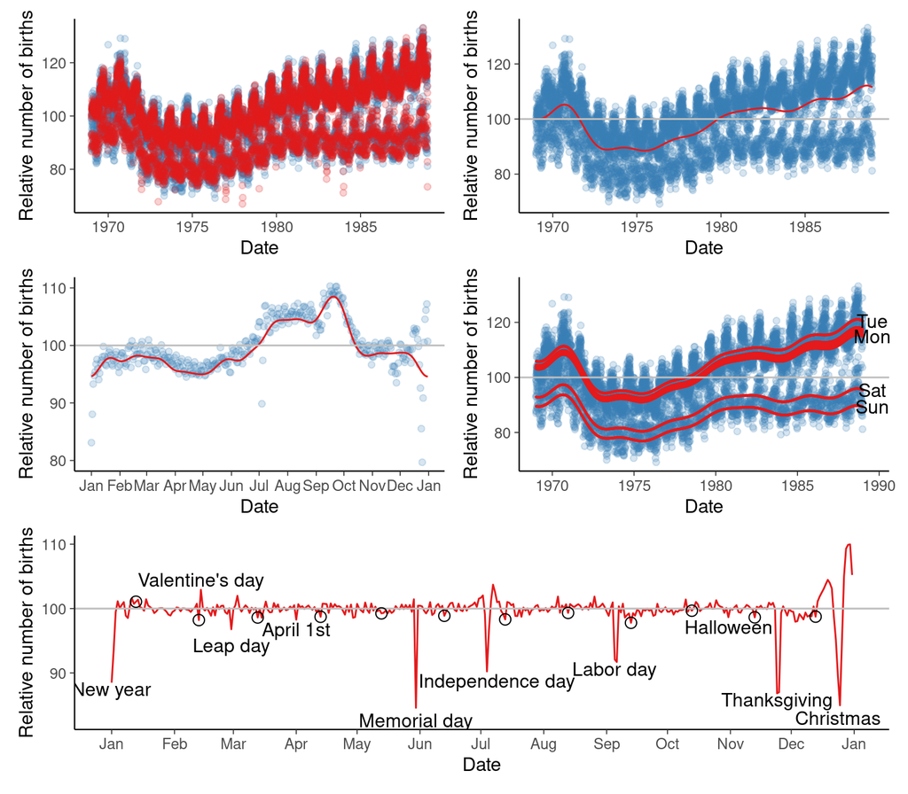

Figure 35

```r
draws8 <- as_draws_matrix(pdraws8)
Ef <- exp(apply(subset(draws8, variable = "f"), 2, median))
Ef1 <- apply(subset(draws8, variable = "f1"), 2, median)
Ef1 <- exp(Ef1 - mean(Ef1) + mean(log(birthdays$births_relative100)))
Ef2 <- apply(subset(draws8, variable = "f2"), 2, median)
Ef2 <- exp(Ef2 - mean(Ef2) + mean(log(birthdays$births_relative100)))
Ef_day_of_week <- apply(subset(draws8, variable = "f_day_of_week"), 2, median)
Ef_day_of_week <- exp(Ef_day_of_week - mean(Ef_day_of_week) + mean(log(birthdays$births_relative100)))
Ef3 <- apply(subset(draws8, variable = "f3"), 2, median)
Ef3 <- exp(Ef3 - mean(Ef3) + mean(log(birthdays$births_relative100)))
Ef4 <- apply(subset(draws8, variable = "beta_f4"), 2, median) * sd(log(birthdays$births_relative100))
Ef4 <- exp(Ef4) * 100
Efloats <- apply(subset(draws8, variable = "beta_f5"), 2, median) * sd(log(birthdays$births_relative100))
Efloats <- exp(Efloats) * 100
floats1988 <- c(memorial_days[20], labor_days[c(20, 40)], thanksgiving_days[c(20, 40)]) - 6939
Ef4float <- Ef4
Ef4float[floats1988] <- Ef4float[floats1988] * Efloats[c(1, 2, 2, 3, 3)] / 100
pf   <- make_pf(birthdays, Ef, fit_geom = "point")
pf1  <- make_pf1(birthdays, Ef1)
pf2  <- make_pf2(birthdays, Ef2)
pf3b <- make_pf3b(birthdays, Ef3, Ef1_vec = Ef1, weekday_labels = TRUE)
f13  <- birthdays |> filter(year == 1988) |> select(day, date) |> mutate(y = Ef4float) |> filter(day == 13)
pf2b <- make_pf2b(Ef4float, f13, holidays = "floating")
compose_6panel(pf, pf1, pf2, pf3b, pf2b)
```

We turn of the PSIS resampling in Stan.

```r
tic('Sampling from Pathfinder approximation of model 6 posterior')
pth8 <- model8$pathfinder(data = standata8, init = 0.1,
                          num_paths = 10, single_path_draws = 40, draws = 400,
                          history_size = 50, max_lbfgs_iters = 100,
                          refresh = 0, psis_resample = FALSE)
```

```
Finished in  9.2 seconds.
```

```r
mytoc()
```

[output not shown]

Sample short chains using the Pathfinder result as initial values (although the result from short chains can be useful in a quick workflow, the result should not be used as the final result).

```r
tic('MCMC sampling from model 8 posterior with Pathfinder initialization')
fit8 <- model8$sample(data = standata8, iter_warmup = 100, iter_sampling = 100,
                      chains = 4, parallel_chains = 4,
                      init = pth8, refresh = 10)
```

```r
mytoc()
```

Check whether parameters have reasonable values

```r
draws8 <- fit8$draws()
summarise_draws(subset(draws8, variable = c("sigma_", "lengthscale_", "sigma"), regex = TRUE)) |>
  tt()
```

| variable | mean | median | sd | mad | q5 | q95 | rhat | ess_bulk | ess_tail |
| --- | --- | --- | --- | --- | --- | --- | --- | --- | --- |
| sigma_f1 | 0.61 | 0.61 | 0.08 | 0.096 | 0.49 | 0.75 | 1.4 | 9.3 | 20 |
| sigma_f2 | 0.28 | 0.27 | 0.042 | 0.038 | 0.22 | 0.36 | 1.5 | 8.6 | 24 |
| sigma_g3 | 0.21 | 0.2 | 0.054 | 0.062 | 0.14 | 0.3 | 1.7 | 6.8 | 46 |
| sigma_f4 | 0.17 | 0.17 | 0.0072 | 0.007 | 0.16 | 0.18 | 1 | 642 | 296 |
| lengthscale_f1 | 0.2 | 0.2 | 0.025 | 0.026 | 0.15 | 0.23 | 1.3 | 12 | 12 |
| lengthscale_f2 | 0.29 | 0.29 | 0.027 | 0.024 | 0.25 | 0.34 | 1.2 | 16 | 54 |
| lengthscale_g3 | 0.69 | 0.71 | 0.18 | 0.18 | 0.37 | 0.96 | 1.5 | 8 | 13 |
| sigma | 0.23 | 0.23 | 0.0019 | 0.0019 | 0.23 | 0.24 | 1 | 418 | 294 |

```r
summarise_draws(subset(draws8, variable = c("beta_f3"))) |>
  tt()
```

| variable | mean | median | sd | mad | q5 | q95 | rhat | ess_bulk | ess_tail |
| --- | --- | --- | --- | --- | --- | --- | --- | --- | --- |
| beta_f3[1] | 0.32 | 0.32 | 0.022 | 0.022 | 0.28 | 0.36 | 1.2 | 14 | 33 |
| beta_f3[2] | 0.085 | 0.085 | 0.011 | 0.012 | 0.065 | 0.1 | 1 | 66 | 323 |
| beta_f3[3] | 0.044 | 0.045 | 0.011 | 0.011 | 0.026 | 0.063 | 1 | 354 | 371 |
| beta_f3[4] | 0.15 | 0.15 | 0.014 | 0.013 | 0.13 | 0.18 | 1.1 | 29 | 101 |
| beta_f3[5] | -1.2 | -1.2 | 0.078 | 0.066 | -1.3 | -1.1 | 1.3 | 11 | 21 |
| beta_f3[6] | -1.6 | -1.6 | 0.1 | 0.085 | -1.8 | -1.5 | 1.3 | 11 | 23 |

Compare the model to the data

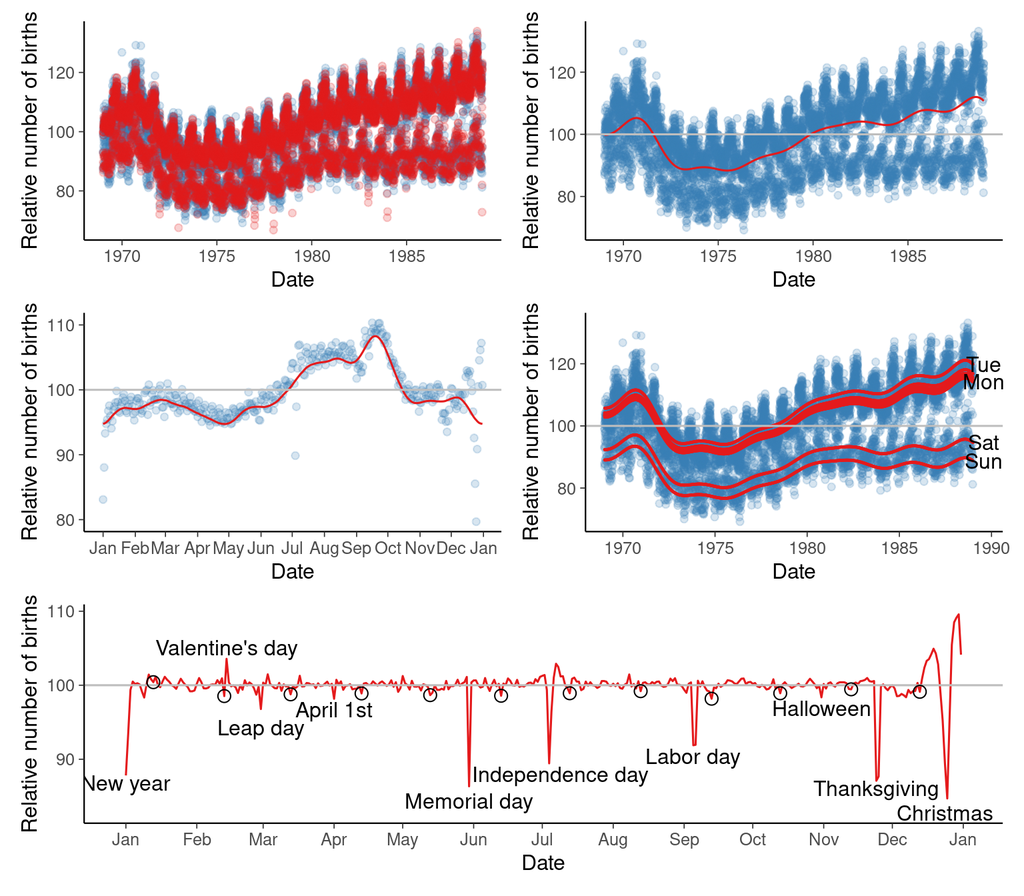

Figure 36

```r
draws8 <- as_draws_matrix(draws8)
Ef <- exp(apply(subset(draws8, variable = "f"), 2, median))
Ef1 <- apply(subset(draws8, variable = "f1"), 2, median)
Ef1 <- exp(Ef1 - mean(Ef1) + mean(log(birthdays$births_relative100)))
Ef2 <- apply(subset(draws8, variable = "f2"), 2, median)
Ef2 <- exp(Ef2 - mean(Ef2) + mean(log(birthdays$births_relative100)))
Ef_day_of_week <- apply(subset(draws8, variable = "f_day_of_week"), 2, median)
Ef_day_of_week <- exp(Ef_day_of_week - mean(Ef_day_of_week) + mean(log(birthdays$births_relative100)))
Ef3 <- apply(subset(draws8, variable = "f3"), 2, median)
Ef3 <- exp(Ef3 - mean(Ef3) + mean(log(birthdays$births_relative100)))
Ef4 <- apply(subset(draws8, variable = "beta_f4"), 2, median) * sd(log(birthdays$births_relative100))
Ef4 <- exp(Ef4) * 100
Efloats <- apply(subset(draws8, variable = "beta_f5"), 2, median) * sd(log(birthdays$births_relative100))
Efloats <- exp(Efloats) * 100
floats1988 <- c(memorial_days[20], labor_days[c(20, 40)], thanksgiving_days[c(20, 40)]) - 6939
Ef4float <- Ef4
Ef4float[floats1988] <- Ef4float[floats1988] * Efloats[c(1, 2, 2, 3, 3)] / 100
pf   <- make_pf(birthdays, Ef, fit_geom = "point")
pf1  <- make_pf1(birthdays, Ef1)
pf2  <- make_pf2(birthdays, Ef2)
pf3b <- make_pf3b(birthdays, Ef3, Ef1_vec = Ef1, weekday_labels = TRUE)
f13  <- birthdays |> filter(year == 1988) |> select(day, date) |> mutate(y = Ef4float) |> filter(day == 13)
pf2b <- make_pf2b(Ef4float, f13, holidays = "floating")
compose_6panel(pf, pf1, pf2, pf3b, pf2b)
```

Compare the mean and sd of parameters from Pathfinder and MCMC. In this case, we are using the non-resampled Pathfinder draws.

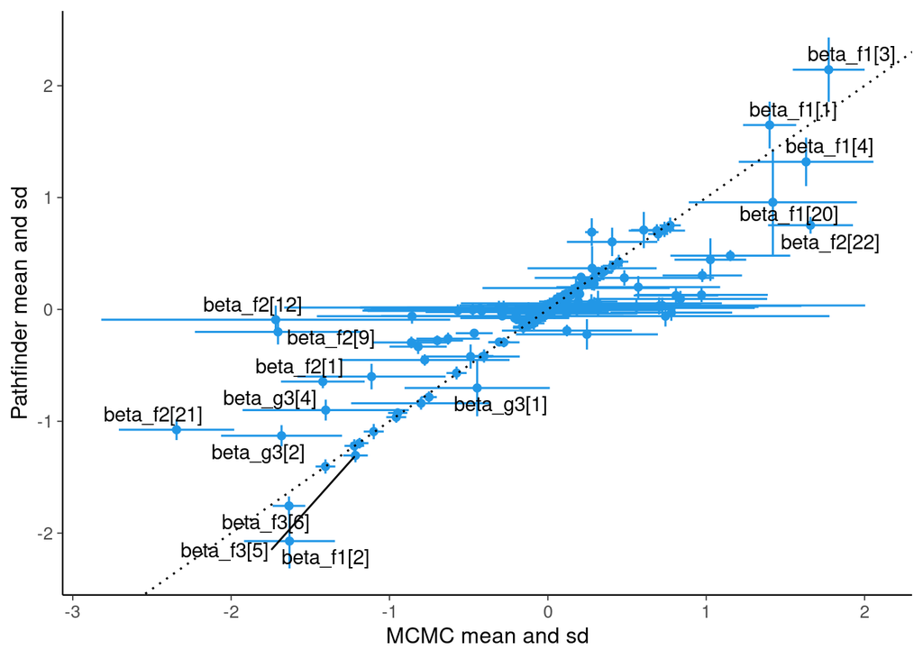

Figure 37

```r
variables <- names(model8$variables()$parameters)
sp <- summarise_draws(subset(pth8$draws(), variable = variables))
sm <- summarise_draws(subset(draws8, variable = variables))
make_pth_vs_fit(sm, sp)
```

## 5.9 Model 8+t_nu: day of year effect with Student’s t prior

Compile Stan model 8 + t_nu gpbf8tnu.stan

```r
model8tnu <- cmdstan_model(stan_file = root("birthdays", "gpbf8tnu.stan"),
                           include_paths = root("birthdays"))
```

Pathfinder is faster than sampling (although this result can be useful in a quick workflow, the result should not be used as the final result). We turn off the resampling in Stan to get distinct draws for initialization of MCMC.

```r
tic('Sampling from Pathfinder approximation of model 8tnu posterior')
pth8tnu <- model8tnu$pathfinder(data = standata8, init = 0.1,
                                num_paths = 10, single_path_draws = 40, draws = 400,
                                history_size = 50, max_lbfgs_iters = 100,
                                refresh = 0, psis_resample = FALSE)
```

```
Finished in  11.8 seconds.
```

```r
mytoc()
```

```
Sampling from Pathfinder approximation of model 8tnu posterior took 12 sec
```

Sample short chains using the Pathfinder result as initial values (although the result from short chains can be useful in a quick workflow, the result should not be used as the final result).

```r
tic('MCMC sampling from model 8tnu posterior with Pathfinder initialization')
fit8tnu <- model8tnu$sample(data = standata8, iter_warmup = 100, iter_sampling = 100,
                            chains = 4, parallel_chains = 4,
                            init = pth8tnu, refresh = 10)
```

```r
mytoc()
```

```
MCMC sampling from model 8tnu posterior with Pathfinder initialization took 240 sec
```

We get a high number of divergences. The posterior clearly has a challenging shape. If we would like to continue using this model, eventually we should fix the computational issues, but before that we can examine the initial results in case we decide to not continue with this model after all.

Check whether parameters have reasonable values

```r
draws8tnu <- fit8tnu$draws()
summarise_draws(subset(draws8tnu, variable = c("intercept", "sigma_", "lengthscale_", "sigma", "nu_"), regex = TRUE)) |>
  tt()
```

| variable | mean | median | sd | mad | q5 | q95 | rhat | ess_bulk | ess_tail |
| --- | --- | --- | --- | --- | --- | --- | --- | --- | --- |
| sigma_f1 | 0.72 | 0.69 | 0.16 | 0.16 | 0.5 | 1 | 1.1 | 49 | 92 |
| sigma_f2 | 0.29 | 0.28 | 0.043 | 0.043 | 0.23 | 0.36 | 1.1 | 28 | 134 |
| sigma_g3 | 0.2 | 0.19 | 0.049 | 0.048 | 0.13 | 0.28 | 1 | 89 | 75 |
| sigma_f4 | 0.0049 | 0.0049 | 0.0017 | 0.002 | 0.0026 | 0.0078 | 1.4 | 8.9 | 54 |
| lengthscale_f1 | 0.21 | 0.22 | 0.035 | 0.031 | 0.16 | 0.26 | 1 | 64 | 129 |
| lengthscale_f2 | 0.21 | 0.21 | 0.015 | 0.014 | 0.18 | 0.23 | 1.1 | 73 | 128 |
| lengthscale_g3 | 0.78 | 0.8 | 0.19 | 0.2 | 0.44 | 1.1 | 1 | 109 | 196 |
| sigma | 0.23 | 0.23 | 0.0019 | 0.0018 | 0.23 | 0.24 | 1 | 301 | 261 |
| nu_f4 | 0.79 | 0.79 | 0.099 | 0.11 | 0.64 | 0.95 | 1.2 | 19 | 226 |

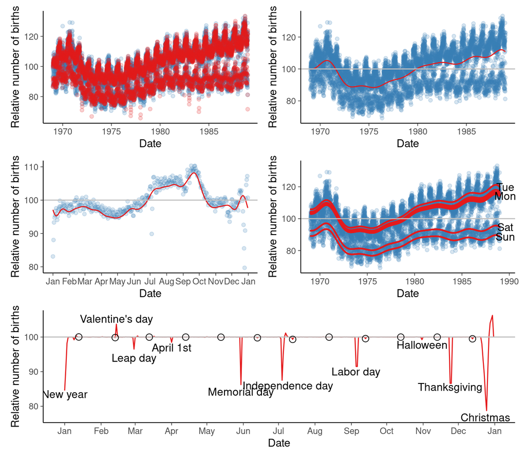

Figure 38

```r
draws8 <- as_draws_matrix(draws8tnu)
Ef <- exp(apply(subset(draws8, variable = "f"), 2, median))
Ef1 <- apply(subset(draws8, variable = "f1"), 2, median)
Ef1 <- exp(Ef1 - mean(Ef1) + mean(log(birthdays$births_relative100)))
Ef2 <- apply(subset(draws8, variable = "f2"), 2, median)
Ef2 <- exp(Ef2 - mean(Ef2) + mean(log(birthdays$births_relative100)))
Ef_day_of_week <- apply(subset(draws8, variable = "f_day_of_week"), 2, median)
Ef_day_of_week <- exp(Ef_day_of_week - mean(Ef_day_of_week) + mean(log(birthdays$births_relative100)))
Ef3 <- apply(subset(draws8, variable = "f3"), 2, median)
Ef3 <- exp(Ef3 - mean(Ef3) + mean(log(birthdays$births_relative100)))
Ef4 <- apply(subset(draws8, variable = "beta_f4"), 2, median) * sd(log(birthdays$births_relative100))
Ef4 <- exp(Ef4) * 100
Efloats <- apply(subset(draws8, variable = "beta_f5"), 2, median) * sd(log(birthdays$births_relative100))
Efloats <- exp(Efloats) * 100
floats1988 <- c(memorial_days[20], labor_days[c(20, 40)], thanksgiving_days[c(20, 40)]) - 6939
Ef4float <- Ef4
Ef4float[floats1988] <- Ef4float[floats1988] * Efloats[c(1, 2, 2, 3, 3)] / 100
pf   <- make_pf(birthdays, Ef, fit_geom = "point")
pf1  <- make_pf1(birthdays, Ef1)
pf2  <- make_pf2(birthdays, Ef2)
pf3b <- make_pf3b(birthdays, Ef3, Ef1_vec = Ef1, weekday_labels = TRUE)
f13  <- birthdays |> filter(year == 1988) |> select(day, date) |> mutate(y = Ef4float) |> filter(day == 13)
pf2b <- make_pf2b(Ef4float, f13, holidays = "floating")
compose_6panel(pf, pf1, pf2, pf3b, pf2b)
```

The other effects seem to be quite similar as with the previous model, but the day of year effects are clearly different with most days having non-detectable effect. There are also effects that seemed to be quite clear in normal prior model such as 13th day of month effect, which is not visible anymore. As the posterior of degrees of freedom `t_nu` was concentrated close to 1, it’s likely that the normal prior for day of year effect can’t be the best. So far we hadn’t used model comparison such as leave-one-out cross-validation (LOO-CV, Vehtari, Gelman, and Gabry (2017)) as each added component had qualitatively big and reasonable effect. Now as day of year effect is sensitive to prior choice, but it’s not clear how much better $t_\nu$ prior distribution is we use LOO-CV to compare the models.

```r
loo8 <- fit8$loo()
loo8tnu <- fit8tnu$loo()
loo_compare(list(`Model 8 normal` = loo8, `Model 8 Student's t` = loo8tnu)) |>
  select(model, elpd_diff, se_diff, p_worse, diag_diff, diag_elpd) |>
  tt() |>
  format_tt(j=4, replace = "-")
```

| model | elpd_diff | se_diff | p_worse | diag_diff | diag_elpd |
| --- | --- | --- | --- | --- | --- |
| Model 8 Student's t | 0 | 0 | - |  | 51 k_psis > 0.62 |
| Model 8 normal | -116 | 16 | 1 |  | 10 k_psis > 0.62 |

As we could have expected based on the posterior of `nu_f4` Student’s t prior on day of year effects is better. As low degrees of freedom indicate a thick tailed distribution for day of year effect is needed, we decided to test again RHS prior.

We did get warnings about high Pareto-$\hat{k}$ values, but as the difference is big, and the normal model is nested in the Student’s $t$ model with the posterior clearly indicating non-normality, we don’t need to fix the LOO computation to trust this specific comparison.

Compare the mean and sd of parameters from Pathfinder and MCMC. In this case, we are using the non-resampled Pathfinder draws.

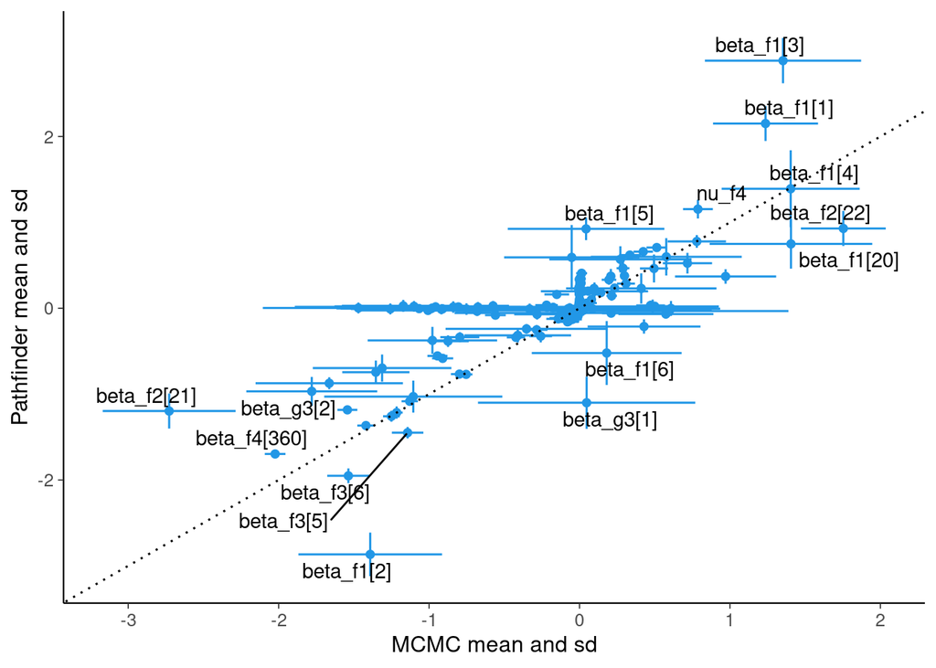

Figure 39

```r
variables <- names(model8tnu$variables()$parameters)
sp <- summarise_draws(subset(pth8tnu$draws(), variable = variables))
sm <- summarise_draws(subset(draws8tnu, variable = variables))
make_pth_vs_fit(sm, sp)
```

## 5.10 Model 8+RHS: day of year effect with RHS prior

Model 5 had RHS prior but the problem was that optimization result wasn’t even close to sensible and MCMC was very slow. Given the other models we now know that the problem is not in adding day of year effect or combining it with time dependent magnitude for the day of week effect. It was easier now to focus on figuring out the problem in RHS. Since RHS is presented as a scale mixture of normals involving hierarchical prior, it is common to use non-centered parameterization for RHS prior. Non-centered parameterization is useful when the information from the likelihood is weak and the prior dependency dominates in the posterior dependency. RHS is often used when there are less observations than unknowns. In this problem each unknown (one day of year effect) is informed by several observations from different years, and then it might be that the centered parameterization is better. And this turned out to be true and the inference for model 8 with centered parameterization RHS prior on day of year effect worked much better than for model 5. (In Stan it was easy to test switch from non-centered to centered parameterization by removing the multiplier from one of the parameter declarations).

Compile Stan model 8 + RHS gpbf8rhs.stan

```r
model8rhs <- cmdstan_model(stan_file = root("birthdays", "gpbf8rhs.stan"),
                           include_paths = root("birthdays"))
```

Add a global scale for RHS prior

```r
standata8 <- c(standata8,
               scale_global = 0.1) # global scale for RHS prior
```

Pathfinder is faster than sampling (although this result can be useful in a quick workflow, the result should not be used as the final result).

```r
tic('Sampling from Pathfinder approximation of model 8rhs posterior')
pth8rhs <- model8rhs$pathfinder(data = standata8, init = 0.1,
                                num_paths = 10, single_path_draws = 40, draws = 400,
                                history_size = 50, max_lbfgs_iters = 100,
                                refresh = 0, psis_resample = FALSE)
```

```
Finished in  17.5 seconds.
```

```r
mytoc()
```

```
Sampling from Pathfinder approximation of model 8rhs posterior took 18 sec
```

Sample short chains using the optimization result as initial values (although the result from short chains can be useful in a quick workflow, the result should not be used as the final result).

```r
tic('MCMC sampling from model 8rhs posterior with Pathfinder initialization')
fit8rhs <- model8rhs$sample(data = standata8, iter_warmup = 100, iter_sampling = 100,
                            chains = 4, parallel_chains = 4,
                            init = pth8rhs, refresh = 10)
```

```r
mytoc()
```

```
MCMC sampling from model 8rhs posterior with Pathfinder initialization took 240 sec
```

We get a high number of divergences. The posterior clearly has a challenging shape. If we would like to continue using this model, eventually we should fix the computational issues, but before that we can examine the initial results in case we decide to not continue with this model after all.

Check whether parameters have reasonable values

```r
draws8rhs <- fit8rhs$draws()
summarise_draws(subset(draws8rhs, variable = c("sigma_", "lengthscale_", "sigma"), regex = TRUE)) |>
  tt()
```

| variable | mean | median | sd | mad | q5 | q95 | rhat | ess_bulk | ess_tail |
| --- | --- | --- | --- | --- | --- | --- | --- | --- | --- |
| sigma_f1 | 0.64 | 0.66 | 0.15 | 0.17 | 0.42 | 0.88 | 2 | 5.9 | 13 |
| sigma_f2 | 0.28 | 0.28 | 0.034 | 0.037 | 0.22 | 0.33 | 1.6 | 7.6 | 23 |
| sigma_g3 | 0.18 | 0.18 | 0.037 | 0.042 | 0.13 | 0.24 | 1.5 | 9.9 | 31 |
| sigma_f4 | 0.086 | 0.081 | 0.044 | 0.047 | 0.023 | 0.16 | 1.5 | 8.8 | 28 |
| lengthscale_f1 | 0.23 | 0.23 | 0.022 | 0.021 | 0.2 | 0.26 | 1.8 | 6.6 | 46 |
| lengthscale_f2 | 0.21 | 0.21 | 0.011 | 0.01 | 0.19 | 0.23 | 1.3 | 12 | 13 |
| lengthscale_g3 | 0.85 | 0.85 | 0.16 | 0.14 | 0.57 | 1.1 | 1.7 | 6.5 | 14 |
| sigma | 0.23 | 0.23 | 0.0018 | 0.0018 | 0.23 | 0.24 | 1.1 | 337 | 256 |

Compare the model to the data

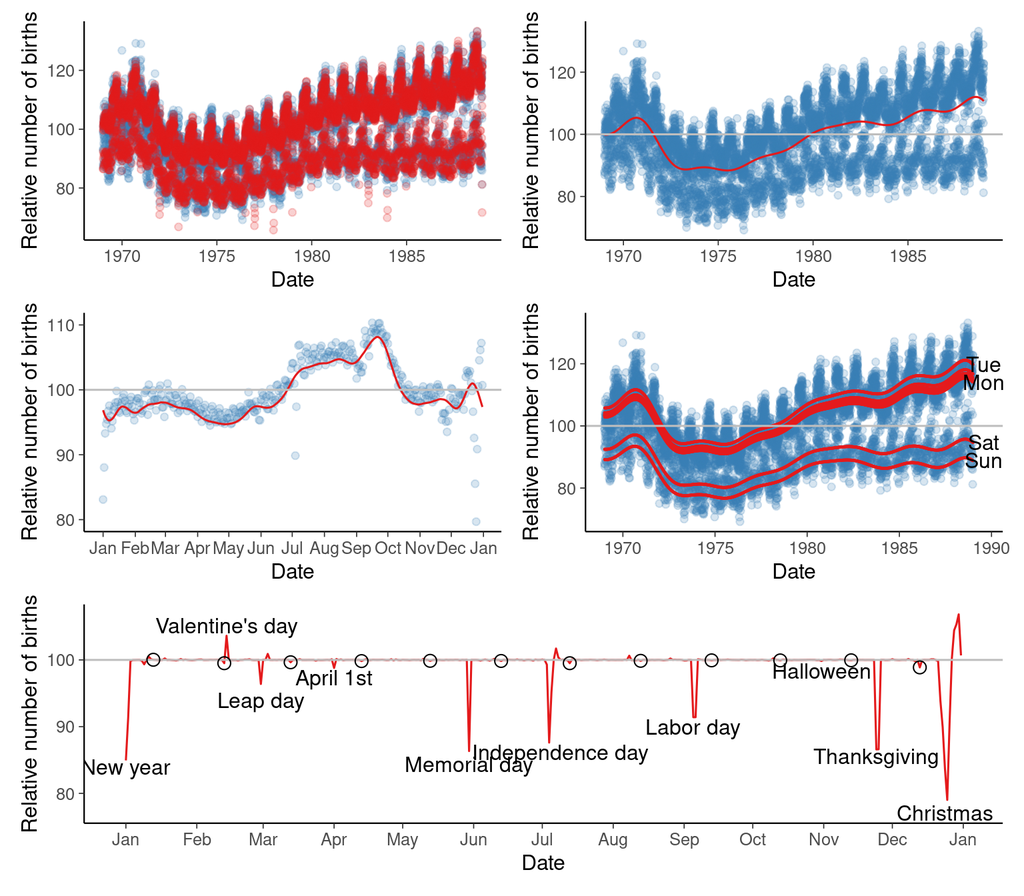

Figure 40

```r
draws8 <- as_draws_matrix(draws8rhs)
Ef <- exp(apply(subset(draws8, variable = "f"), 2, median))
Ef1 <- apply(subset(draws8, variable = "f1"), 2, median)
Ef1 <- exp(Ef1 - mean(Ef1) + mean(log(birthdays$births_relative100)))
Ef2 <- apply(subset(draws8, variable = "f2"), 2, median)
Ef2 <- exp(Ef2 - mean(Ef2) + mean(log(birthdays$births_relative100)))
Ef_day_of_week <- apply(subset(draws8, variable = "f_day_of_week"), 2, median)
Ef_day_of_week <- exp(Ef_day_of_week - mean(Ef_day_of_week) + mean(log(birthdays$births_relative100)))
Ef3 <- apply(subset(draws8, variable = "f3"), 2, median)
Ef3 <- exp(Ef3 - mean(Ef3) + mean(log(birthdays$births_relative100)))
Ef4 <- apply(subset(draws8, variable = "beta_f4"), 2, median) * sd(log(birthdays$births_relative100))
Ef4 <- exp(Ef4) * 100
Efloats <- apply(subset(draws8, variable = "beta_f5"), 2, median) * sd(log(birthdays$births_relative100))
Efloats <- exp(Efloats) * 100
floats1988 <- c(memorial_days[20], labor_days[c(20, 40)], thanksgiving_days[c(20, 40)]) - 6939
Ef4float <- Ef4
Ef4float[floats1988] <- Ef4float[floats1988] * Efloats[c(1, 2, 2, 3, 3)] / 100
pf   <- make_pf(birthdays, Ef, fit_geom = "point")
pf1  <- make_pf1(birthdays, Ef1)
pf2  <- make_pf2(birthdays, Ef2)
pf3b <- make_pf3b(birthdays, Ef3, Ef1_vec = Ef1, weekday_labels = TRUE)
f13  <- birthdays |> filter(year == 1988) |> select(day, date) |> mutate(y = Ef4float) |> filter(day == 13)
pf2b <- make_pf2b(Ef4float, f13, holidays = "floating")
compose_6panel(pf, pf1, pf2, pf3b, pf2b)
```

```r
loo8rhs <- fit8rhs$loo()
loo_compare(list(`Model 8 Student's t` = loo8tnu, `Model 8 RHS` = loo8rhs)) |>
  select(model, elpd_diff, se_diff, p_worse, diag_diff, diag_elpd) |>
  tt() |>
  format_tt(j=4, replace = "-")
```

| model | elpd_diff | se_diff | p_worse | diag_diff | diag_elpd |
| --- | --- | --- | --- | --- | --- |
| Model 8 RHS | 0 | 0 | - |  | 196 k_psis > 0.62 |
| Model 8 Student's t | -0.21 | 3.9 | 0.52 | \|elpd_diff\| < 4 | 51 k_psis > 0.62 |

Compare the mean and sd of parameters from Pathfinder and MCMC. In this case, we are using the non-resampled Pathfinder draws.

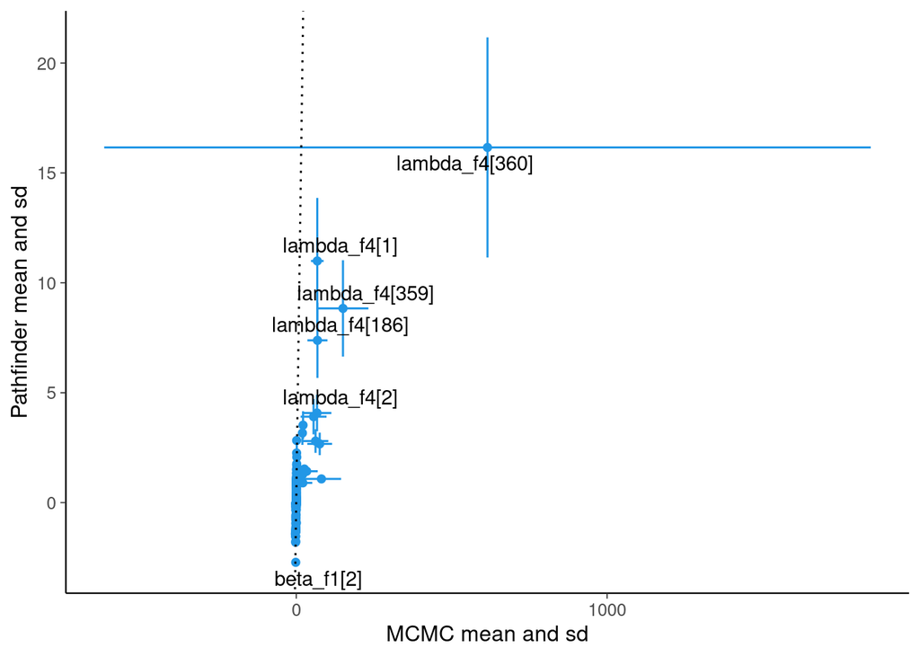

Figure 41

```r
variables <- names(model8rhs$variables()$parameters)
sp <- summarise_draws(subset(pth8rhs$draws(), variable = variables))
sm <- summarise_draws(subset(draws8rhs, variable = variables))
make_pth_vs_fit(sm, sp)
```

`lambda_f4` is a vector parameter for scale mixture presentation of RHS prior, and it is a weakly identifiable which can explain bigger differences between Pathfinder and MCMC than for other parameters.

### 5.10.1 Further improvements for the day of year effect

It’s unlikely that day of year effect would be unstructured with some distribution like RHS, and thus instead of trying to find a prior distribution that would improve LOO-CV, it would make more sense to further add structural information. For example, it would be possible to add more known special days and take into account that a special day effect and weekend effect probably are not additive. Furthermore if there are less births during some day, the births need to happen some other day and it can be assumed that there would be corresponding excess of births before of after a bank holiday. This ringing around days with less births is not simple as it is also affected whether the previous and following days are weekend days. This all gets more complicated than we want to include in this case study, but the reader can see how the similar gradual model building could be made by adding additional components. Eventually it is likely that there starts to be worry of overfitting, but integration over the unknown alleviates that and looking at the predictive performance estimates such LOO-CV can help to decide when the additional model components don’t improve the predictive performance or can’t be well identified.

### 5.10.2 Quantitative predictive performance for the series of models

We didn’t use LOO-CV (Vehtari, Gelman, and Gabry 2017) until in the end, as the qualitative differences between models were very convincing. We can use LOO-CV to check how big the difference in the predictive performance are and if the differences are big, we know that model averaging that would take into account the uncertainty would give weights close to zero for all but the most elaborate models.

```r
loo1 <- fit1$loo()
loo2 <- fit2$loo()
loo3 <- fit3$loo()
loo4 <- fit4$loo()
loo6 <- fit6$loo()
loo7 <- fit7$loo()
loo_compare(list(`Model 1` = loo1, `Model 2` = loo2, `Model 3` = loo3, `Model 4` = loo4, `Model 6` = loo6, `Model 7` = loo7, `Model 8 + RHS` = loo8rhs)) |>
  select(model, elpd_diff, se_diff, p_worse, diag_diff, diag_elpd) |>
  tt() |>
  format_tt(j=4, replace = "-")
```

| model | elpd_diff | se_diff | p_worse | diag_diff | diag_elpd |
| --- | --- | --- | --- | --- | --- |
| Model 8 + RHS | 0 | 0 | - |  | 196 k_psis > 0.62 |
| Model 7 | -960 | 48 | 1 |  | 13 k_psis > 0.62 |
| Model 6 | -1557 | 89 | 1 |  | 9 k_psis > 0.62 |
| Model 4 | -1992 | 130 | 1 |  |  |
| Model 3 | -2476 | 115 | 1 |  |  |
| Model 2 | -8490 | 102 | 1 |  | 1 k_psis > 0.62 |
| Model 1 | -9032 | 103 | 1 |  |  |

### 5.10.3 Residual analysis

We can get further ideas for how to improve the model also by looking at the residuals.

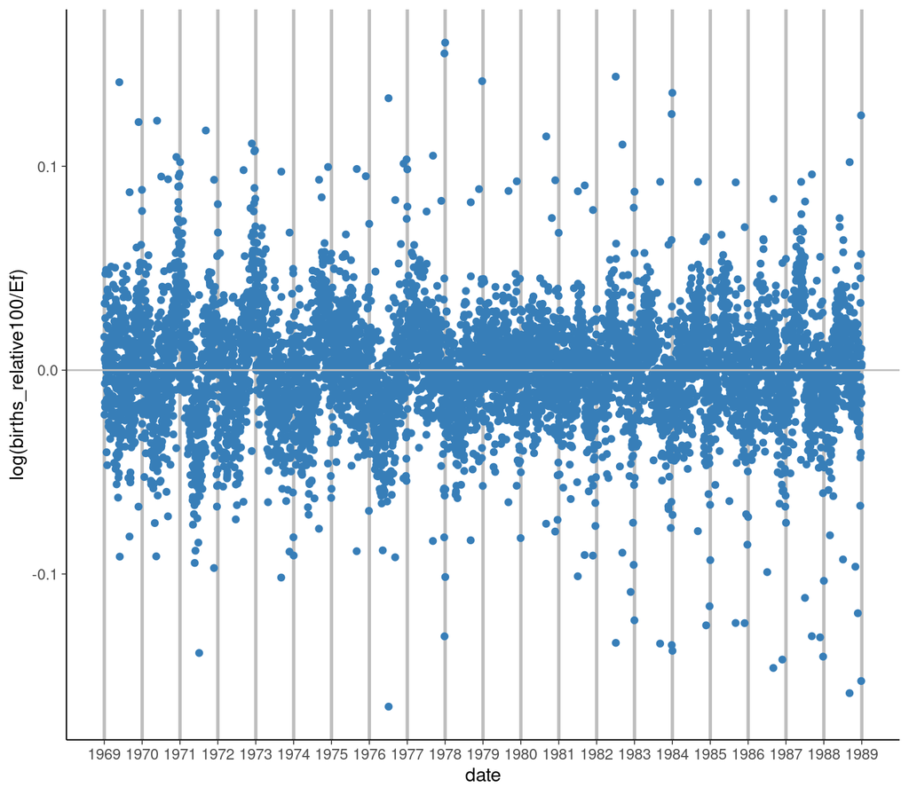

Figure 42

```r
draws8 <- as_draws_matrix(draws8rhs)
Ef <- exp(apply(subset(draws8, variable = "f"), 2, median))
birthdays |>
  mutate(Ef = Ef) |>
  ggplot(aes(x = date, y = log(births_relative100 / Ef))) +
  geom_point(color = col_data) +
  geom_hline(yintercept = 0, color = "gray") +
  scale_x_date(date_breaks = "1 year", date_labels = "%Y") +
  theme(panel.grid.major.x = element_line(color = "gray", linewidth = 1))
```

We can see some structure, specifically in years 1969–1978 the residual has negative peak in the middle of the year, while in years 1981–1988 the residual has positive peak in the middle of the year. This kind of pattern appears as we use the same seasonal effect for all years, but the magnitude of seasonal effect is changing. It would be possible to modify the model to include gradually changing seasonal effect, but leave it out from this case study.

```r
draws8 <- as_draws_matrix(draws8tnu)
f <- exp(subset(draws8, variable = "f"))
loo8tnu <- fit8tnu$loo(save_psis = TRUE)
Efloo <- E_loo(f, psis_object = loo8tnu$psis_object)$value
LOOR2 <- 1 - var(log(birthdays$births_relative100 / Efloo)) / var(log(birthdays$births_relative100))
data.frame(Model = "Model 8 Student's t", `LOO-R2` = LOOR2) |>
  tt()
```

| Model | LOO.R2 |
| --- | --- |
| Model 8 Student's t | 0.94 |

As it seems we could still improve by adding more structure and time varying seasonal effect, it seems the variability in the number of births from day to day is quite well predictable. Of course big part of the variation is due to planned induced births and c-sections, and thus hospitals do already control the number of births per day and there is no really practical use for the result. However there are plenty of similar time series, for example, in consumer behavior that are affected by special days.

Above we used the same Stan model code for Pathfinder and MCMC which included generated quantities. If we want to use Pathfinder just for initialization, and trust it so that we don’t need to check the generated quantities we can drop that out (or call it separately).

```r
model8rhs_nogq <- cmdstan_model(stan_file = root("birthdays", "gpbf8rhs_nogq.stan"),
                                include_paths = root("birthdays"),
                                cpp_options = list(stan_threads = TRUE))
```

```r
tic('Sampling from Pathfinder approximation of model 8rhs posterior')
pth8rhs <- model8rhs_nogq$pathfinder(data = standata8, init = 0.1,
                                num_threads = 10,
                                num_paths = 10, single_path_draws = 40, draws = 400,
                                history_size = 50, max_lbfgs_iters = 100,
                                refresh = 0, psis_resample = FALSE)
```

```
Finished in  6.5 seconds.
```

```r
mytoc()
```

```
Sampling from Pathfinder approximation of model 8rhs posterior took 6.7 sec
```

As the generated quantities are not computed and written to the csv, the time in my laptop drops to 3s.

Above we created the MCMC initial values using PSIS resampling without replacement. When the Pathfinder is used just for initializing MCMC, we could further reduce the time by getting less draws. If we are worried of getting stuck in minor modes, we could still run more paths than the required number of initial values and resample without replacement in hope of dropping out the draws from the minor modes. At the moment (2024-01-21) there is a bug so that minimum number of draws per path is 25.

```r
tic('Sampling from Pathfinder approximation of model 8rhs posterior')
pth8rhs <- model8rhs_nogq$pathfinder(data = standata8, init = 0.1,
                                num_threads = 10,
                                num_paths = 10, single_path_draws = 1, draws = 10,
                                history_size = 50, max_lbfgs_iters = 100,
                                refresh = 0, psis_resample = FALSE)
```

```
Finished in  6.5 seconds.
```

```r
mytoc()
```

```
Sampling from Pathfinder approximation of model 8rhs posterior took 6.6 sec
```

There is not much time saving and the number of paths run dominate.

If we are not worried about the minor modes we could run just 4 paths. At the moment (2024-01-21) there is a bug so that minimum number of draws per path is 25, but these draws the ones used to estimate ELBO, so there is no additional computational cost.

```r
tic('Sampling from Pathfinder approximation of model 8rhs posterior')
pth8rhs <- model8rhs_nogq$pathfinder(data = standata8, init = 0.1,
                                num_threads = 4,
                                num_paths = 4, single_path_draws = 1, draws = 4,
                                history_size = 50, max_lbfgs_iters = 100,
                                refresh = 0, psis_resample = FALSE)
```

```
Finished in  3.6 seconds.
```

```r
mytoc()
```

```
Sampling from Pathfinder approximation of model 8rhs posterior took 3.7 sec
```

With my laptop, it takes about 1.5s to run 4 paths to get 4 distinct draws to initialize MCMC.

Alternatively we could run just one path with 4 draw from the normal approximation.

```r
tic('Sampling from Pathfinder approximation of model 8rhs posterior')
pth8rhs <- model8rhs_nogq$pathfinder(data = standata8, init = 0.1,
                                num_threads = 4,
                                num_paths = 1, single_path_draws = 4, draws = 4,
                                history_size = 50, max_lbfgs_iters = 100,
                                refresh = 0, psis_resample = FALSE)
```

```
Finished in  2.1 seconds.
```

```r
mytoc()
```

```
Sampling from Pathfinder approximation of model 8rhs posterior took 2.2 sec
```

The time goes down to less than 1s, but these draws are likely to have less variation than draws from multi-Pathfinder.

Earlier we plotted mean and sd of several parameters based on MCMC and Pathfinder. Without generated quantities, we can easily increase the number of draws from the normal approximation to improve such mean and sd estimates, without increasing the computation time much.

```r
tic('Sampling from Pathfinder approximation of model 8rhs posterior')
pth8rhs <- model8rhs_nogq$pathfinder(data = standata8, init = 0.1,
                                     num_threads = 10,
                                     num_paths = 40, single_path_draws = 100, draws = 4000,
                                     history_size = 50, max_lbfgs_iters = 100,
                                     refresh = 0, psis_resample = FALSE)
```

```
Finished in  25.1 seconds.
```

```r
mytoc()
```

```
Sampling from Pathfinder approximation of model 8rhs posterior took 25 sec
```

Compare the mean and sd of some parameters from Pathfinder and MCMC. In this case, we are using the non-resampled Pathfinder draws.

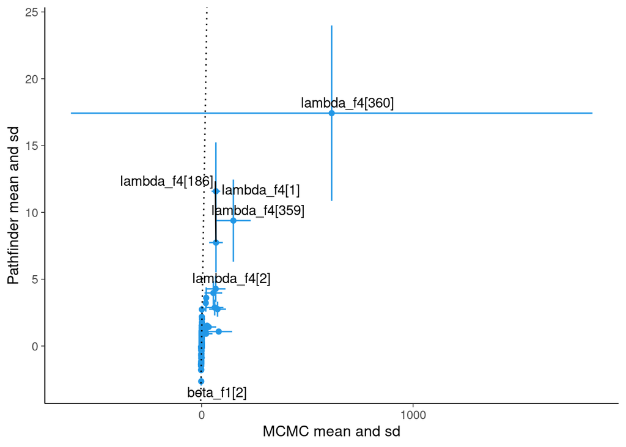

Figure 43

```r
variables <- names(model8rhs$variables()$parameters)
sp <- summarise_draws(subset(pth8rhs$draws(), variable = variables))
sm <- summarise_draws(subset(draws8rhs, variable = variables))
make_pth_vs_fit(sm, sp, max.overlaps = 20)
```

Plot the sd from Pathfinder divided by sd from MCMC. We see that for some parameters the order of magnitude is fine, but for some sd is underestimated by 2-3 orders of magnitude, which would make these estimates bad for initializing the mass matrix.

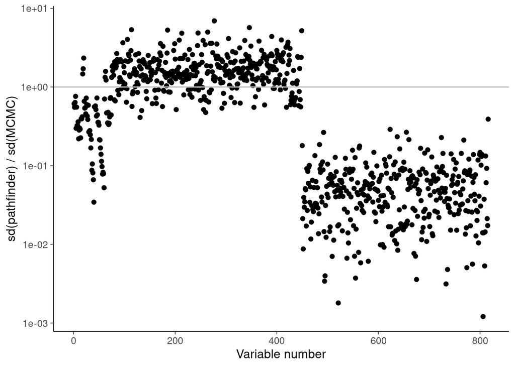

Figure 44

```r
make_sd_ratio(sm, sp)
```

In case of simpler models, Pathfinder estimates can be much better. For example, for the model 1b we get the following

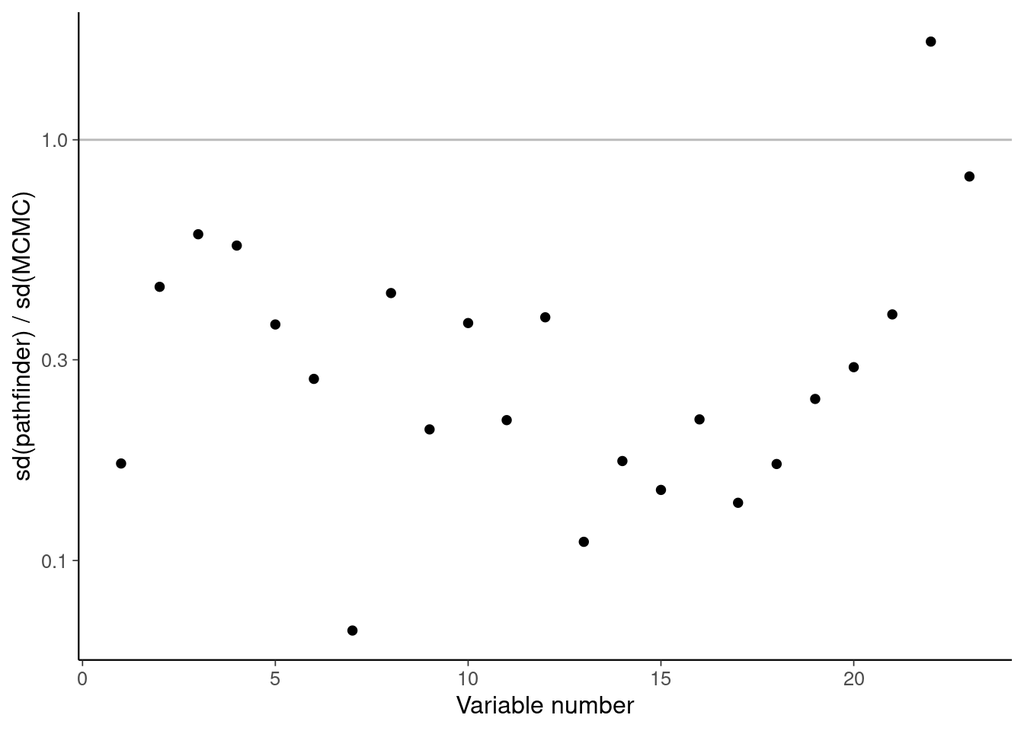

Figure 45

```r
variables <- names(model1b$variables()$parameters)
sp <- summarise_draws(subset(pth1b$draws(), variable = variables))
sm <- summarise_draws(subset(draws1b, variable = variables))
make_sd_ratio(sm, sp)
```

### 5.10.4 More accurate inference

```r
tic('MCMC sampling 4000 draws from model 8tnu posterior with earlier fit initialization')
fit8tnu <- model8tnu$sample(data = standata8, chains = 4, parallel_chains = 4,
                            iter_warmup = 500, adapt_delta = 0.95, init = fit8tnu)
```

```r
mytoc()
```

```
MCMC sampling 4000 draws from model 8tnu posterior with earlier fit initialization took 1400 sec
```

Using this final model which is the best model based on LOO-CV comparison, we show the day of year effect with 90% posterior intervals.

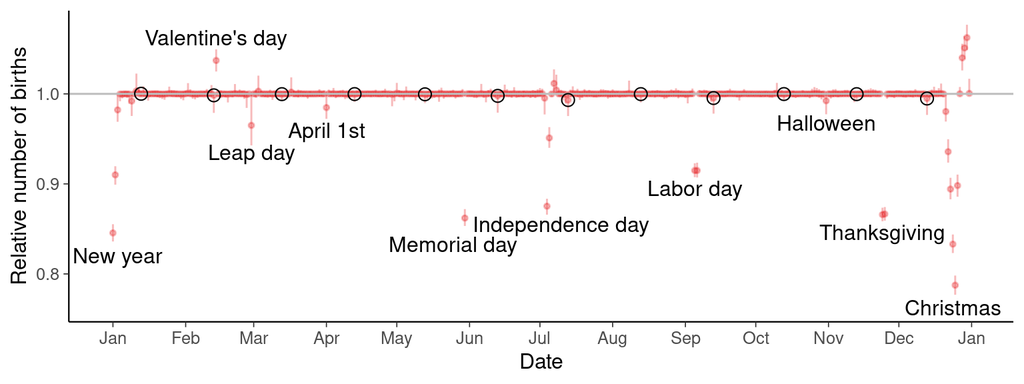

Figure 46

```r
draws8tnur <- as_draws_rvars(draws8tnu)
Ef4r <- exp(draws8tnur$beta_f4*sd(log(birthdays$births_relative100)))
Efloatsr <- exp(draws8tnur$beta_f5*sd(log(birthdays$births_relative100)))
floats1988 <- c(memorial_days[20], labor_days[c(20, 40)], thanksgiving_days[c(20, 40)]) - 6939
Ef4floatr <- Ef4r
Ef4floatr[floats1988] <- Ef4floatr[floats1988] * Efloatsr[c(1, 2, 2, 3, 3)]
draws8tnu <- as_draws_matrix(draws8tnu)
Ef4 <- apply(subset(draws8tnu, variable = "beta_f4"), 2, median) * sd(log(birthdays$births_relative100))
Ef4 <- exp(Ef4)
Efloats <- apply(subset(draws8tnu, variable = "beta_f5"), 2, median) * sd(log(birthdays$births_relative100))
Efloats <- exp(Efloats)
floats1988 <- c(memorial_days[20], labor_days[c(20, 40)], thanksgiving_days[c(20, 40)]) - 6939
Ef4float <- Ef4
Ef4float[floats1988] <- Ef4float[floats1988] * Efloats[c(1, 2, 2, 3, 3)]
f13  <- birthdays |> filter(year == 1988) |> select(day, date) |> mutate(y = Ef4float) |> filter(day == 13)
pf2c <- make_pf2c(Ef4float, Ef4floatr, f13, holidays = "floating")
pf2c
```

In this plot, it seems like there is no 13th day effect. However, if we look at the mean effect over all 13th days, the probability that the relative number of births is less than 1 is 99.75%, although with a small estimated effect of 0.4% fewer births.

Although the final model used here for the day of year effects was the best according to LOO-CV, it is likely that there are similarly good models with slightly different priors that can influence how much the effects are shrunk to mean. In this case, this modeling is just for illustration of the computational workflow and for real life prediction models, much more thinking can be done to improve the model

# References

Gelman, Andrew, John B Carlin, Hal S Stern, David B Dunson, Aki Vehtari, and Donald B Rubin. 2013. *Bayesian Data Analysis*. Third edition. CRC Press.

McLatchie, Y., and A. Vehtari. 2024. “Efficient Estimation and Correction of Selection-Induced Bias with Order Statistics.” *Statistics and Computing* 34 (132).

Navarro, Danielle J. 2019. “Between the Devil and the Deep Blue Sea: Tensions Between Scientific Judgement and Statistical Model Selection.” *Computational Brain & Behavior* 2 (1): 28–34.

Piironen, Juho, and Aki Vehtari. 2017. “Sparsity Information and Regularization in the Horseshoe and Other Shrinkage Priors.” *Electronic Journal of Statistics* 11: 5018–51.

Riutort-Mayol, Gabriel, Paul-Christian Bürkner, Michael R Andersen, Arno Solin, and Aki Vehtari. 2023. “Practical Hilbert Space Approximate Bayesian Gaussian Processes for Probabilistic Programming.” *Statistics and Computing* 33 (1): 17.

Vehtari, Aki, Andrew Gelman, and Jonah Gabry. 2017. “Practical Bayesian Model Evaluation Using Leave-One-Out Cross-Validation and WAIC.” *Statistics and Computing* 27: 1413–32.

Vehtari, Aki, Daniel Simpson, Andrew Gelman, Yuling Yao, and Jonah Gabry. 2024. “Pareto Smoothed Importance Sampling.” *Journal of Machine Learning Research* 25 (72): 1–58.

Zhang, Lu, Bob Carpenter, Andrew Gelman, and Aki Vehtari. 2022. “Pathfinder: Parallel Quasi-Newton Variational Inference.” *Journal of Machine Learning Research* 23 (306).

# Licenses

- Code © 2020–2025, Aki Vehtari, licensed under BSD-3.
- Text © 2020–2025, Aki Vehtari, licensed under CC-BY-NC 4.0.